# Introduction to Durga

`Durga` is an R package that aims to simplify the estimation and visualisation of one type of effect size: differences in group means. The package consists of two main functions and several auxiliary functions. The `DurgaDiff` function estimates raw or standardised mean differences, while `DurgaPlot` will create a plot for visualising both the original data and the effect size, and provides an extensive range of display options. The function `DurgaBrackets` can add *confidence brackets* to an existing Durga plot. Since `Durga` is implemented in base R, Durga plots can be positioned using the standard R plotting layout tools: `par(mfrow = c(...))`, `layout()` and `split.screen()`.

This vignette shows some example Durga plots. Each plot is preceded by the code used to generate it, which can be used to learn how to create the plot.

## Effect size estimation

### Long format data

Before plotting your data, you must estimate the differences in group means by calling `DurgaDiff`. Your raw data should be in a data frame (or similar) in either *long* or *wide* format. A long format data frame contains one observation per row, a column for the measurement or value being analysed, and another column for the group or treatment. In addition, paired or repeated measures data requires an ID column to match measurements for the same specimen/individual. For example, within the `insulin` data set, the value being measured - blood sugar level - is recorded in the column `sugar` (specified in the `DurgaDiff` call by passing the argument `data.col = "sugar"`); treatments are `"before"` and `"after"` in the `treatment` column (`group.col = "treatment"`); and the identity of the individual (rabbit) being tested is given in the `id` column (`id.col = "id"`). The blood sugar level of each rabbit was tested before and after treatment with insulin, so for each rabbit, there is a row with the `before` sugar level, and another with the `after` sugar level. Both long and wide format can be used to represent paired and unpaired data, however long format is most appropriate for unpaired data.

```r
# Inspect the insulin data set, paired data in long format
head(insulin[insulin$id < 4, ])
```

```
##    sugar treatment id experimenter_time time
## 1  0.111    before  1        ECN FEB 16   NA
## 2  0.139    before  2        ECN APR 22   NA
## 3  0.129    before  3        ECN APR 22   NA
## 53 0.045     after  1        ECN FEB 16   35
## 54 0.075     after  2        ECN APR 22   45
## 55 0.056     after  3        ECN APR 22   60
```

```r
# Calculate differences in group means
d <- DurgaDiff(insulin, data.col = "sugar", group.col = "treatment", id.col = "id")
d
```

```
## Bootstrapped effect size
##   sugar ~ treatment
## Groups:
##              mean median         sd          se   CI.lower   CI.upper  n
## after  0.07038462  0.071 0.01785250 0.002475697 0.06545157 0.07519795 52
## before 0.12726923  0.127 0.01522397 0.002111185 0.12314735 0.13144397 52
## Paired Mean of differences (R = 1000, bootstrap CI method = bca):
##   before - after: 0.0568846, 95% CI [0.0511501, 0.0629732]
```

### Formula interface

When your data set is in long format, you may alternatively identify your data with a formula. The formula interface allows a little more flexibility when specifying your model, but the end results are equivalent. The formula must be specified as `<data variable> ~ <group variable>`. The data table must be in long format. For paired data, specify the `id` column using the `id.col` argument.

```r
# Use a formula to define the model
DurgaDiff(sugar ~ treatment, insulin, id.col = "id")
```

```
## Bootstrapped effect size
##   sugar ~ treatment
## Groups:
##              mean median         sd          se   CI.lower   CI.upper  n
## after  0.07038462  0.071 0.01785250 0.002475697 0.06549376 0.07500021 52
## before 0.12726923  0.127 0.01522397 0.002111185 0.12321154 0.13190010 52
## Paired Mean of differences (R = 1000, bootstrap CI method = bca):
##   before - after: 0.0568846, 95% CI [0.0510858, 0.062979]
```

### Wide format data

DurgaDiff also accepts data in *wide format*. A wide format data frame contains a measurement column for each group. For example, an experiment with a control and a treatment might comprise a column named `control` and another named `treatment`. To pass wide format data to `DurgaDiff`, do not specify the `data.col` or `group.col` arguments. Instead, you must identify the groups in your data with the `groups` argument. Each group must be the name of a column in the data frame. Wide format may be a natural way to represent paired data, as each row represents a specimen. Wide format is not as appropriate for unpaired data, as a single row will contain measurements from two (or more) unrelated specimens, although Durga will handle it. To use wide format with unpaired data, specify `id.col = NULL`. If your groups have different sample sizes, you will also have to specify `na.rm = TRUE`.

```r
# Inspect the wide insulin data set
head(insulin.wide)
```

```
##   sugar.before sugar.after time experimenter   date
## 1        0.111       0.045   35          ECN FEB 16
## 2        0.139       0.075   45          ECN APR 22
## 3        0.129       0.056   60          ECN APR 22
## 4        0.132       0.067   35          ECN APR 25
## 5        0.145       0.060   90          FGB  APR 6
## 6        0.151       0.071  120          FGB APR 10
```

```r
# Calculate differences in group means
(d <- DurgaDiff(insulin.wide, groups = c("sugar.before", "sugar.after")))
```

```
## Bootstrapped effect size
##   value ~ group
## Groups:
##                    mean median         sd          se   CI.lower   CI.upper  n
## sugar.before 0.12726923  0.127 0.01522397 0.002111185 0.12278846 0.13105769 52
## sugar.after  0.07038462  0.071 0.01785250 0.002475697 0.06526918 0.07448683 52
## Paired Mean of differences (R = 1000, bootstrap CI method = bca):
##   sugar.after - sugar.before: -0.0568846, 95% CI [-0.0628107, -0.0511401]
```

### Effect types

Durga can estimate unstandardised or various standardised group differences, which are specified using the DurgaDiff parameter `effect.type`. Chapter 11, Cohen’s d in Cumming (2012) is a good reference for understanding standardised effect sizes and the importance of choosing the appropriate standardiser. The online help for DurgaDiff summarises the effect types that are built-in to Durga.

## Plotting

The simplest plot to create simply uses all default values. This plot shows raw data points displayed as individual data points, the distribution of data points within each group shown as half violins, and *effect size* to the right (for a single group comparison) or beneath the group data (for multiple comparisons).

The *effect size* is an estimate of the difference in means between two groups (or a similar statistic). It is shown with a symbol (a triangle by default) at the estimated value, and a thick line showing the confidence interval of the estimate. A filled half-violin shows the distribution of bootstrapped effect sizes, truncated at the top and bottom so it does not extend past the confidence interval.

If the data are paired (aka repeated measures; `id.col` was specified in the `DurgaDiff` call), then pair lines are drawn to connect measurements for the same individual/specimen.

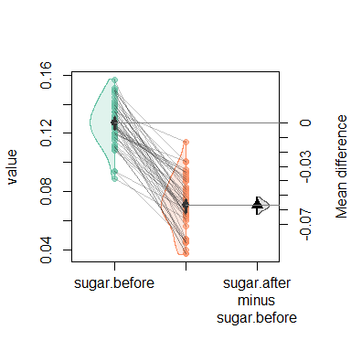

```r
DurgaPlot(d)
```

### Plot components

A `DurgaPlot` data visualisation is a combination of one or more visual components: data `points`; `violin` plots; `bar` charts; `box` plots; repeated measure `paired` lines; a mean or median indicator (`central.tendency`); and error bars (`error.bars`). Each component is controlled by a set of parameters to the `DurgaPlot` function. The names of the parameters indicate the component they apply to, so to adjust the violin plot component, read the documentation about all parameters with prefix `violin`. Effect size display is controlled by parameters with prefix `ef.size`. Parameters have sensible default values, so for example, if you display bar charts (`bar = TRUE`), violin plots and the central tendency indicator will be turned off. Obviously, you are able to override the defaults if you wish. Refer to help for the `DurgaPlot` function for full details on all arguments.

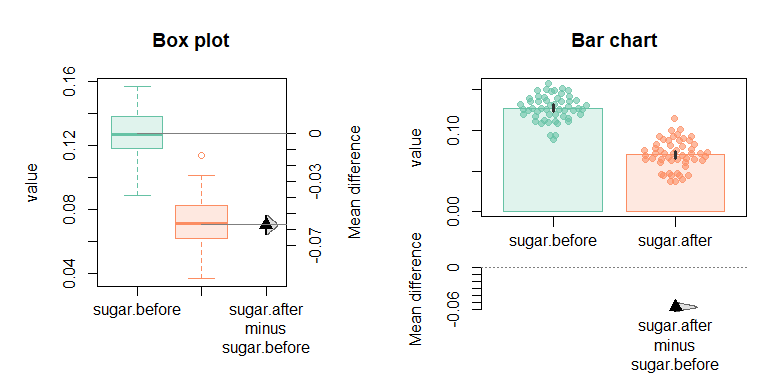

```r
# Show two plots in the same figure, and increase margins so they don't look crowded
par(mfrow = c(1, 2), mar = c(5, 5, 4, 5) + 0.1)

DurgaPlot(d,
          # Display box plots
          box = TRUE,
          # Don't display data points
          points = FALSE,
          # Don't display paired-value lines
          paired = FALSE,
          main = "Box plot")

par(mar = c(5, 5, 4, 1) + 0.1)

DurgaPlot(d,
          # Display bar charts
          bar = TRUE,
          # Position effect size below
          ef.size.position = "below",
          # No paired-value lines
          paired = FALSE,
          main = "Bar chart")
```

### Group order and labels

In the damselfly data set, the groups are `juvenile` and `adult`. The example below demonstrates how to change the displayed group names as well as the display order of the groups.

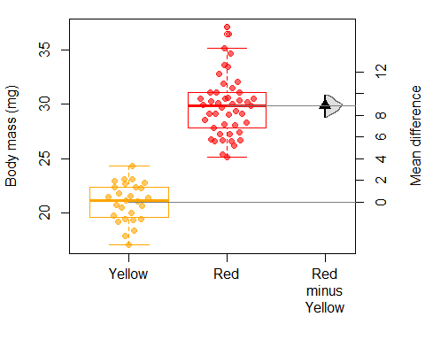

```r
# No title on this plot, so reduce the top margin size
par(mar = c(5, 4, 1, 1) + 0.1)

# Immature males are yellow, mature are red. Display juveniles first, and label
# with colour rather than developmental stage
d <- DurgaDiff(mass ~ maturity, damselfly, na.rm = TRUE,
               groups = c("Yellow" = "juvenile", "Red" = "adult"))
DurgaPlot(d,
          # Custom y-axis label
          left.ylab = "Body mass (mg)",
          # Specify the colours to (approximately) match the data
          group.colour = c("orange", "red"),
          box = TRUE, box.fill = FALSE)
```

If you need greater control over the display of the group labels, for example to display in italics or bold, set the `group.names` field in the DurgaDiff object. It must be a vector of characters or expressions, one for each group.

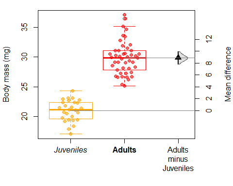

```r
# No title on this plot, so reduce the top margin size
par(mar = c(5, 4, 1, 1) + 0.1)

# Immature males are yellow, mature are red. Display juveniles first, and label
# with colour rather than developmental stage
d <- DurgaDiff(mass ~ maturity, damselfly, na.rm = TRUE,
               groups = c("Juveniles" = "juvenile", "Adults" = "adult"))
d$group.names <- c(expression(italic("Juveniles")), expression(bold("Adults")))
DurgaPlot(d,
          # Custom y-axis label
          left.ylab = "Body mass (mg)",
          # Specify the colours to (approximately) match the data
          group.colour = c("orange", "red"),
          box = TRUE, box.fill = FALSE)
```

### Colours

Colours can be specified for each group (`group.colour`; demonstrated above), or separately for individual components. The *master* argument for each component type controls whether the component is displayed and optionally its colour. So, to display blue violins, specify `violin = "blue"`. To use the default colour, specify `violin = TRUE`. Colours can be specified as the name of an [RColorBrewer](https://r-graph-gallery.com/38-rcolorbrewers-palettes.html) palette (e.g. `group.colour = "Dark2"`), or as one or more R colours.

Colours for data points receive special treatment; points can be coloured individually or by group. If there are as many colours as data points, the points are coloured individually. Otherwise, colours are applied to groups (excess colours are ignored). The default point symbol (`pch`) is 19.

The convenience function `DurgaTransparent` adds transparency to a colour, so `DurgaTransparent("blue", 0.8)` is a nearly-transparent blue colour.

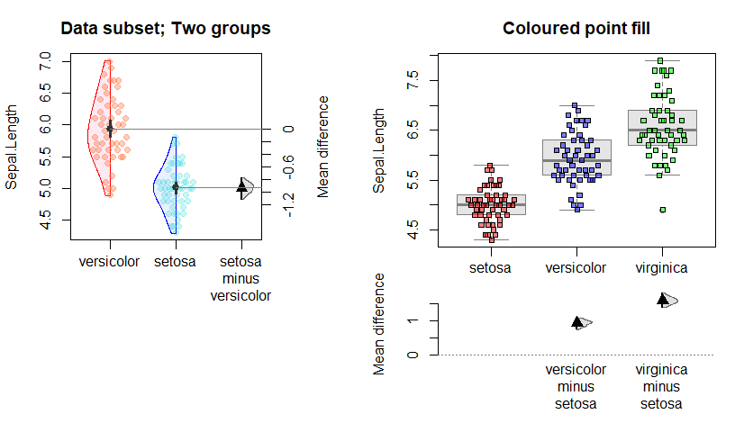

```r
par(mfrow = c(1, 2), mar = c(11, 4, 3, 6) + 0.1)
# Only show 2 groups even though there are 3 in the data
d <- DurgaDiff(iris, data.col = "Sepal.Length", group.col = "Species",
                   groups = c("versicolor", "setosa"))
DurgaPlot(d,
          # Custom colours for points - the points are partially transparent
          points = c(DurgaTransparent("coral", .6), DurgaTransparent("darkturquoise", .8)),
          # Different colurs for violin (border) and violin fill
          violin = c("red", "blue"), violin.fill = c("#f8a8c840", "#a8c8f840"),
          main = "Data subset; Two groups")

par(mar = c(5, 4, 3, 1) + 0.1)
d <- DurgaDiff(iris, data.col = "Sepal.Length", group.col = "Species")
# Define colours for the 3 species
bgCols <- c(DurgaTransparent("red", 0.5),
            DurgaTransparent("blue", 0.5),
            DurgaTransparent("green", 0.5))
DurgaPlot(d,
          # Make all boxes the same colour
          box = "grey50", box.fill = "grey90",
          # Black for border/outline colour of points
          points = "black",
          # Additional data point parameters: small squares filled with colour for species
          points.params = list(pch = 22, cex = 0.8, bg = bgCols[iris$Species]),
          main = "Coloured point fill")
```

### Central tendency and error bars

The central tendency indicator displays either the mean or median of each group (controlled by the `central.tendency.type` argument), and is shown by default when neither boxes nor bars are shown.

Error bars on each group may show: 95% confidence intervals of the mean; standard deviation; or standard error (specified by setting the `error.bars.type` parameter), and may be plotted regardless of what other components are shown.

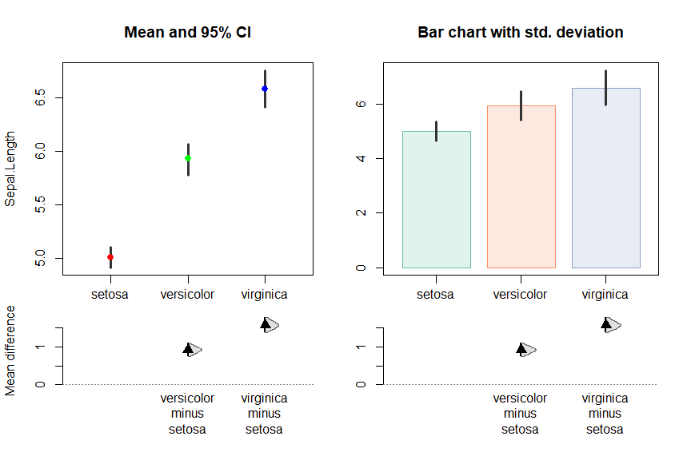

```r
par(mfrow = c(1, 2))
d <- DurgaDiff(iris, data.col = "Sepal.Length", group.col = "Species")

# Only show error bars (95% CI) and central tendency
DurgaPlot(d, error.bars.type = "CI",
          # Custom colour for central tendency
          central.tendency = rainbow(3),
          points = FALSE, violin = FALSE, main = "Mean and 95% CI")

par(mar = c(5, 2.4, 4, 2) + 0.1)
DurgaPlot(d, bar = TRUE, error.bars.type = "SD", points = FALSE,
          left.ylab = "", ef.size.label = "",
          main = "Bar chart with std. deviation")
```

### Plotting multiple effect sizes

The default behaviour of `DurgaDiff` is to calculate differences between all pairs of groups; each difference is a *contrast* and has an estimated effect size with confidence interval. When plotted, each of multiple effect sizes is positioned below the first group in the contrast. This can cause layout problems when one group participates in multiple contrasts. For example, the iris dataset (available within standard R) contains three species: `setosa`, `versicolor` and `virginica`, hence three possible contrasts: `virginica - versicolor`, `virginica - setosa` and `versicolor - setosa`. If all three effect sizes are plotted, two of them (`virginica - versicolor` and `virginica - setosa`) will be positioned at the same horizontal location, resulting in superimposed text and an illegible graph (panel **a)** below)!

There are several ways around this problem:

1. display a subset of possible contrasts;
2. swap the order of groups in a contrast so there is at most one effect size underneath each group;
3. manually adjust effect size horizontal positions (achieved using the parameter `ef.size.dx`; exactly how to do this is left as an exercise for the reader);
4. use *confidence brackets* to depict effect sizes (described below).

There is no single best solution to this problem. The appropriate method depends on your data and the information that you wish to communicate.

To avoid this problem in default plots, the default behaviour of `DurgaPlot` is to assume that the first group is a control, and then show the differences between all subsequent groups and the control (method **1.**). This behaviour prevents effect sizes from overwriting each other, but may exclude pertinent data from the plot (panel **b)** below).

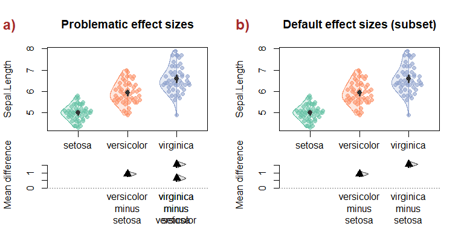

```r
par(mfrow = c(1, 2))

di <- DurgaDiff(iris, "Sepal.Length", "Species")

DurgaPlot(di, contrasts = "*", main = "Problematic effect sizes")
mtext("a)", cex = 1.5, col = "brown", font = 2, adj = -0.3, line = 1.4)

DurgaPlot(di, main = "Default effect sizes (subset)")
mtext("b)", cex = 1.5, col = "brown", font = 2, adj = -0.3, line = 1.4)
```

### Confidence brackets

When there are too many group comparisons for the effect sizes to be clearly displayed, you can choose to display confidence brackets above the plot by calling `DurgaBrackets` after calling `DurgaPlot`. Confidence brackets communicate less information than the standard effect size visualisation, but may be a reasonable compromise for many group comparisons.

You must manually ensure there is sufficient space for the brackets in the plot (see `DurgaBrackets` for details). In the example below, to create space above the plot, we increase the top margin size and prevent the frame from being drawn around the plot (`frame.plot = FALSE`).

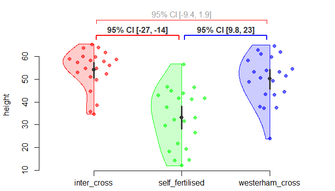

```r
d <- DurgaDiff(petunia, 1, 2)
# Use the top margin for brackets
op <- par(mar = c(2, 4, 4, 1) + 0.1)

# Custom group colours
cols = rainbow(3)

# Save return value from DurgaPlot
p <- DurgaPlot(d,
               # Don't draw effect size because we will draw brackets
               ef.size = FALSE,
               # Don't draw frame because brackets will appear in the upper margin
               frame.plot = FALSE,
               # Custom group colours
               group.colour = cols)

# Customise colours by drawing brackets with the colour of the taller group.
# Get the taller group from each difference
tallerIdx <- sapply(d$group.differences, function(diff) {
  # If the group difference > 0, the first group is taller
  ifelse(diff$t0 > 0, diff$groupIndices[1], diff$groupIndices[2])
  })

# Draw the brackets
DurgaBrackets(p, labels = "level CI", br.col = cols[tallerIdx])
```

### Layout

Each graphical group component (points, violin plot, box plot, bar chart, central tendency indicator, error bar and axis label) is positioned or centred horizontally on x-axis locations from 1 to *n*, where *n* is the number of groups. Group horizontal locations can be shifted with the `group.dx` parameter. For example, `group.dx = 0.1` would shift all groups to the right by 1/10th of the distance between groups. Values are repeated as necessary, so `group.dx = c(0.1, -0.1)` will move each pair of groups closer together.

`group.dx` shifts all components equally, however, to provide fine-grained control, each component can be shifted independently. For example, to shift all *violins* left and all *points* right, specify `violin.dx = -0.12, points.dx = 0.1`.

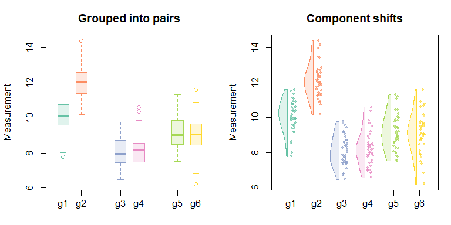

```r
par(mfrow = c(1, 2), mar = c(3, 4, 3, 1) + 0.1)

# Construct some data with multiple groups
set.seed(1) # Ensure we always get the exact same data set
multiGroupData <- data.frame(Measurement = unlist(lapply(c(10, 12, 8, 8.5, 9, 9.1),
                                                         function(m) rnorm(40, m))),
                             Group = rep(paste0("g", 1:6), each = 40),
                             Id = rep(1:6, 40))
d <- DurgaDiff(multiGroupData, 1, 2)

DurgaPlot(d,
          # Visually group each pair
          group.dx = c(0.18, -0.18),
          # Show box plots
          box = TRUE,
          # Make the boxes narrow
          box.params = list(boxwex = 0.4),
          # Don't display effect size or data points
          ef.size = FALSE, points = FALSE,
          xlim = c(0.8, 6.2), # Reduce white space on plot left and right
          main = "Grouped into pairs")

DurgaPlot(d,
          # Shift violins left
          violin.dx = -0.12,
          # Shift points right
          points.dx = 0.1,
          # Make points small and jittered
          points.params = list(cex = 0.5), points.method = "jitter",
          # No central tendency indicator
          central.tendency = FALSE,
          ef.size = FALSE, main = "Component shifts")
```

`group.dx` is implemented very simply as a default value for various other `*.dx` arguments. That means that values such as `violin.dx` are not added to `group.dx`; rather they replace it. Under some circumstances, it can be more convenient if `*.dx` values are added to `group.dx`. You can achieve this in your own code by storing `group.dx` in a variable, then adding relative offsets for other arguments.

```r
# Example snippet, make *.dx arguments relative to group.dx
group.dx <- c(0.75, 0)  # Shift group 1 right, leave group 2 unchanged
DurgaPlot(..., group.dx = group.dx,
          central.tendency.dx = group.dx + 0.1, # Shift mean & error bars right
          violin.dx = group.dx + c(-0.4, -0.5), # Shift violins left
          ef.size.dx = -0.5)
```

## Advanced techniques

### Labelling effect sizes

By default, effect sizes are “mean” (aka unstandardised), which means they are in the same units as the data. However, `DurgaDiff` can estimate standardised effect sizes - either Cohen’s d or Hedges’ g - which allow comparisons of effect sizes across data in different units.

You can override the y-axis labels to aid interpretation of effect sizes. `DurgaPlot` does not provide text labels for standardised effect sixes by default because effect size interpretation depends on context.

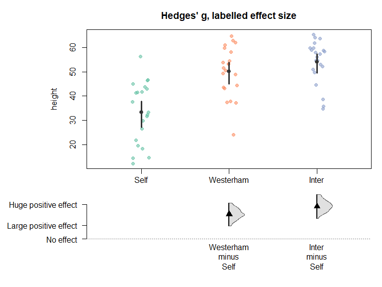

```r
par(mar = c(5, 9, 3, 1) + 0.1)

# Define effect size labels and their positions on the y-axis
effectSizes <- c("No effect" = 0, "Large positive effect" = 0.8, "Huge positive effect" = 2)

# Give the groups friendly names
groups <- c("Self" = "self_fertilised", "Westerham" = "westerham_cross", "Inter" = "inter_cross")

# Calculate bias-corrected Cohen's d, named Hedges' g, rather than unstandardised difference in means
d <- DurgaDiff(petunia, 1, 2, effect.type = "hedges g", groups = groups)

DurgaPlot(d, violin = FALSE, main = "Hedges' g, labelled effect size",
          points.method = "jitter",
          # Use our ticks and labels instead of default
          ef.size.ticks = effectSizes,
          # Horizontal tick labels
          ef.size.params = list(las = 1),
          # Don't label the effect size y-axis because it won't fit with the long tick labels
          ef.size.label = "")
```

### Custom statistics

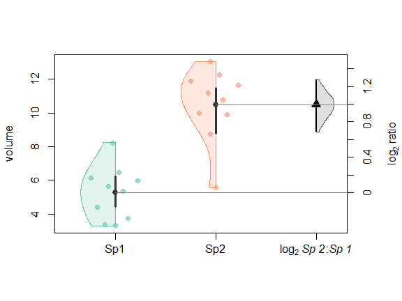

```r
# Define a function that calculates the statistic for two vectors
log2Ratio <- function(x1, x2) log2(mean(x2) / mean(x1))

# Generate some random data
set.seed(1)
data <- data.frame(species = rep(c("Sp1", "Sp2"), each = 10),
                   volume = c(rnorm(10, mean = 5, sd = 2), rnorm(10, mean = 10, sd = 2)))

# Apply log2Ratio as the effect type
d <- DurgaDiff(data, "volume", "species", effect.type = log2Ratio)

# Apply custom labels to describe the effect type, since it is not Sp2 - Sp1
d$group.differences[[1]]$label.plot <- expression("log"[2] ~ italic("Sp 2") * ":" * italic("Sp 1"))

# Plot, and set the y-axis label for effect size
DurgaPlot(d, ef.size.label = expression("log"[2]~"ratio"))
```

```r
# It is also possible to set the label to be used for printing to the console
d$group.differences[[1]]$label.print <- "log2 Sp 2:Sp 1"
d
```

```
## Bootstrapped effect size
##   volume ~ species
## Groups:
##          mean    median       sd        se CI.lower  CI.upper  n
## Sp1  5.264406  5.513151 1.561172 0.4936859 4.433125  6.231468 10
## Sp2 10.497690 10.983745 2.139030 0.6764206 8.796348 11.489956 10
## Unpaired Custom effect type (R = 1000, bootstrap CI method = bca):
##   log2 Sp 2:Sp 1: 0.995729, 95% CI [0.69323, 1.27465]
```

Durga implements a variety of standardisers, but what if you wish to calculate an effect size that is not implemented by Durga? The following example shows one way to use the `cohens_d` function from the [effectsize](https://easystats.github.io/effectsize/index.html) R package with Durga.

```r
# Create a new function that calls effectsize::cohens_d and returns just the calculated statistic
myCohensAv <- function(x1, x2) {
  # Note that we swap the arguments because Durga expects the calculation to be x2 - x1
  cd <- effectsize::cohens_d(x2, x1, pooled_sd = FALSE)
  # Extract and return just the Cohen's d value
  cd$Cohens_d
}
# Pass it in to DurgaDiff as the effect.type
d <- DurgaDiff(petunia, 1, 2, effect.type = myCohensAv)

# Specify the effect type label
DurgaPlot(d, ef.size.label = expression("Cohen's d"))
```

## Examples

This example shows the use of custom group order and display names, contrasts between relevant pairs of groups rather than between all combinations of groups, and various custom plotting options.

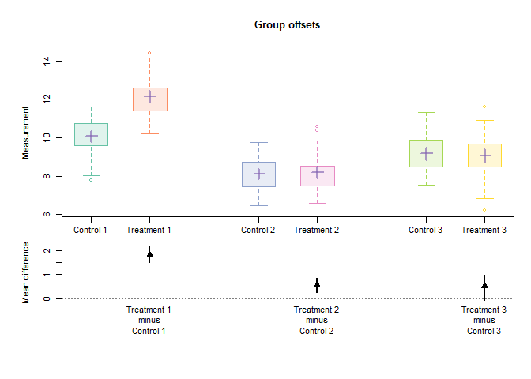

```r
par(mar = c(5, 4, 3, 1) + 0.1)

# Define display order and display pretty group names
groups = c("Control 1" = "g1", "Treatment 1" = "g2",
           "Control 2" = "g3", "Treatment 2" = "g4",
           "Control 3" = "g5", "Treatment 3" = "g6")
d <- DurgaDiff(multiGroupData, 1, 2, 3, groups = groups,
                   contrasts = "g2 - g1, g4 - g3, g6 - g5")
# Reduce text size
par(cex = 0.7)
DurgaPlot(d, box = TRUE,
          # Group into pairs
          group.dx = c(0.15, -0.15),
          # Don't display points
          points = FALSE,
          # Adjust plot width to reduce left/right wasted space
          xlim = c(1, 6),
          # Don't display pair lines
          paired = FALSE,
          # Hide the boxplot median line (medcol = NA) and make the boxes narrow (boxwex = 0.4)
          box.params = list(medcol = NA, boxwex = 0.4),
          # Display mean and error bar
          central.tendency = "#8060b0a0",      # Display and colour central tendency
          central.tendency.symbol = "segment",
          central.tendency.width = 0.07,
          error.bars = "#8060b0a0",            # Same colour for error bars
          # Don't display the effect size violin
          ef.size.violin = FALSE,
          main = "Group offsets"
        )
```

Any unknown parameters to `DurgaPlot` are passed on to the plot function, which allows some control over additional aspects of the plot. The labels underneath effect sizes can be controlled by passing a named vector for the `DurgaPlot` `contrasts` parameter.

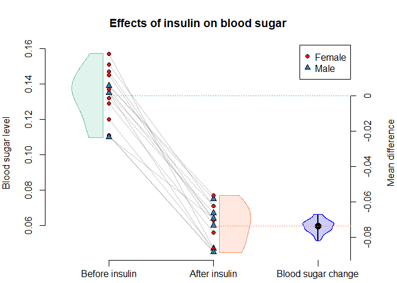

```r
# Add in some fake sex data to the insulin data set
data <- cbind(insulin, Sex = sample(c("Male", "Female"), nrow(insulin), replace = TRUE))
# Thin the data so that individual symbols are visible.
# Obviously these data manipulations are for plot demonstration purposes only
data <- data[data$id %in% 1:15, ]

d <- DurgaDiff(data, "sugar", "treatment", "id",
                   groups = c("Before insulin" = "before", "After insulin" = "after"), na.rm = TRUE)
par(mar = c(2, 4, 4, 1))
# Use different colours to show sex
cols <- RColorBrewer::brewer.pal(3, "Set1")
DurgaPlot(d,
          # Don't draw containing box
          frame.plot = FALSE,
          # Relabel the contrasts
          contrasts = c("Blood sugar change" = "after - before"),
          left.ylab = "Blood sugar level",
          # Customise the violins
          violin.shape = c("left", "right"), violin.dx = c(-0.055, 0.055), violin.width = 0.3,
          # Customise the points to display sex
          points = "black",
          points.params = list(bg = ifelse(data$Sex == "Female", cols[1], cols[2]),
                               pch = ifelse(data$Sex == "Female", 21, 24)),
          # Customise the effect size
          ef.size.pch = 19,
          ef.size.violin = "blue",
          ef.size.violin.shape = "full",
          # Make mean lines match group colour
          ef.size.line.col = RColorBrewer::brewer.pal(3, "Set2")[2:1],
          ef.size.line.lty = 3,
          central.tendency = FALSE,
          main = "Effects of insulin on blood sugar")
# Add a legend
legend("topright", c("Female", "Male"), pch = c(21, 24), pt.bg = cols)
```

Below is an alternative representation for the insulin dataset, showing overlayed rain cloud plots. Positioning is achieved by manually adjusting the relative positions of the various components, using the appropriate `*.dx` parameters.

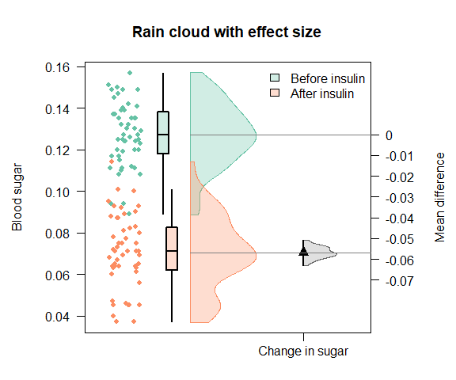

```r
d <- DurgaDiff(insulin, "sugar", "treatment", "id",
               groups = c("Before insulin" = "before", "After insulin" = "after"), na.rm = TRUE)

# Change effect size tick label
d$group.differences[[1]]$label.plot <- "Change in sugar"

# Horizontal axis tick labels, move y-axis labels outwards to make space for the
# horizontal ticks, and ensure the margins are large enough to show them
par(las = 1, mgp = c(4, 1, 0), mar = c(3, 5.5, 4, 5.5) + 0.1)

cols <- RColorBrewer::brewer.pal(3, "Set2")
colsTr <- DurgaTransparent(cols, 0.7)
DurgaPlot(d, paired = FALSE,
          # Move 2nd group to be at the same position as 1st
          group.dx = c(0.2, -0.8),
          # X-axis ticks are meaningless since both groups are at the same location
          x.axis = FALSE,
          # Adjust plot width and spacing
          xlim = c(0.7, 2.1),
          violin = TRUE, violin.shape = "right", violin.fill = colsTr,
          # No need to specify violin position because violin.dx defaults to group.dx
          # Bumpy violins
          violin.adj = 1,
          # Box plots are black outlines
          box = "black", box.dx = c(0.06, -0.895), box.fill = colsTr,
          # Don't show outliers
          box.outline = FALSE,
          # Thin boxes, solid thick lines
          box.params = list(boxwex = 0.06, lty = 1, lwd = 2,
                            # normal line weight for median line
                            medlwd = 2,
                            # no end of whisker line
                            staplecol = NA),
          # Points as solid colours, slightly smaller than default
          points = cols, points.params = list(pch = 16, cex = 0.8),
          points.method = "jitter", points.dx = c(-0.14, -1.14), points.spread = 0.09,
          # Move effect size left to near where 2nd group would have been
          ef.size.dx = -1.2,
          left.ylab = "Blood sugar",
          main = "Rain cloud with effect size"
)

legend("topright", c("Before insulin", "After insulin"), col = cols, fill = colsTr, bty = "n")
```

## Suggestions? Problems?

The source code for Durga is available at github.com/KhanKawsar/EstimationPlot. We welcome suggestions for improvements or reports of problems. Let us know by [logging an issue](https://github.com/KhanKawsar/EstimationPlot/issues) on GitHub.

The Durga [GitHub page](https://github.com/KhanKawsar/EstimationPlot) has additional information such as how to install the latest development version of Durga.

## References

- Cumming, G. (2012). Understanding the new statistics : effect sizes, confidence intervals, and meta-analysis (1st ed.). New York: Routledge.
- Khan, M. K., & McLean, D. J. (2023). Durga: An R package for effect size estimation and visualisation. bioRxiv, 2023.2002.2006.526960. [doi:10.1101/2023.02.06.526960](https://doi.org/10.1101/2023.02.06.526960)